# Lab 7 - Multiple Linear Regression

Chase Tarr

11/8/2021

```r
knitr::opts_chunk$set(echo = TRUE, message = FALSE, warning = FALSE)

# Attach the packages we need

library(tidyverse)
library(palmerpenguins)
library(GGally)
library(broom)
library(kableExtra)
library(modelsummary)
library(stargazer)
```

## Intro to ggpairs

- Use GGally::ggpairs() function to create a pairs plot

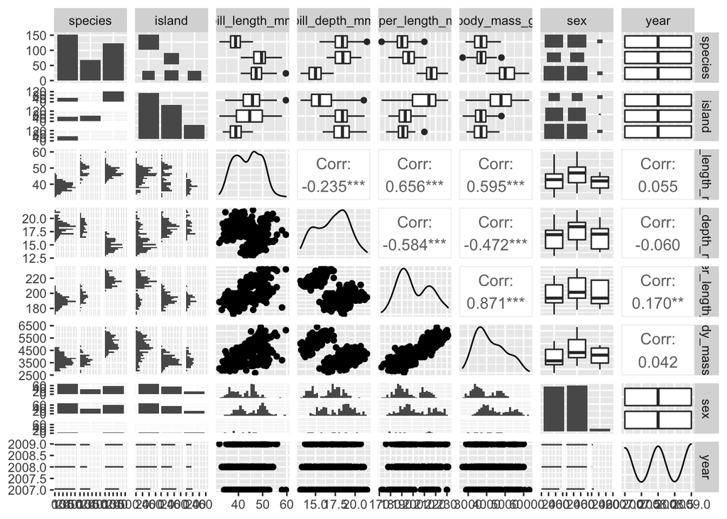

```r
ggpairs(penguins)
```

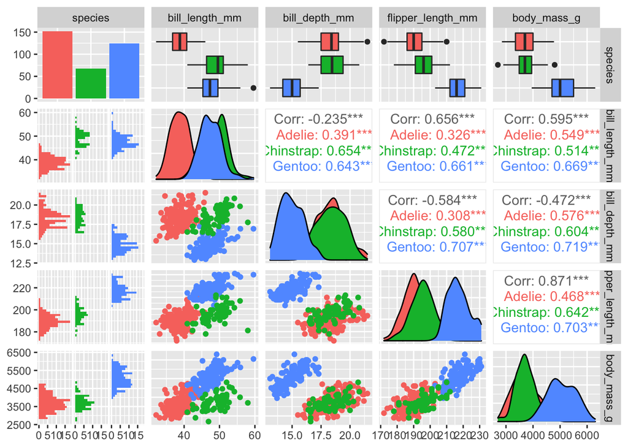

```r
penguins %>%
  select(species, bill_length_mm:body_mass_g) %>% # selecting columns
  ggpairs(aes(color = species))
```

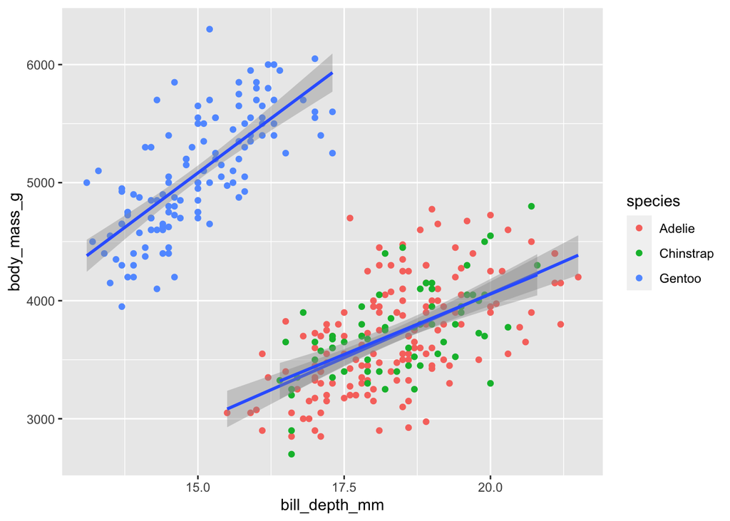

```r
ggplot(data = penguins, aes(x = bill_depth_mm, y = body_mass_g, group = species)) +
  geom_point(aes(color = species)) + # critical to use the right variable included or excluded
  geom_smooth(method = "lm")
```

## Multiple Linear Regression - Penguins

- Use multiple linear regression to try to understand the relationship between multiple predictor variables and a single continuous outcome variable (body mass).

```r
penguin_lm <- lm(body_mass_g ~ flipper_length_mm + bill_depth_mm, data = penguins)

# return just the coefficients:
penguin_lm
```

```
##
## Call:
## lm(formula = body_mass_g ~ flipper_length_mm + bill_depth_mm,
##     data = penguins)
##
## Coefficients:
##       (Intercept)  flipper_length_mm      bill_depth_mm
##          -6541.91              51.54              22.63
```

How would you interpret this coefficient for flipper_length_mm? - On average, we would expect a 51.54 gram increase in penguin body mass for every 1mm increase in flipper length if everything else is held constant. **USE IN LINE CODE REFERENCING**

Use `summary()` function to get more information

```r
summary(penguin_lm)
```

```
##
## Call:
## lm(formula = body_mass_g ~ flipper_length_mm + bill_depth_mm,
##     data = penguins)
##
## Residuals:
##      Min       1Q   Median       3Q      Max
## -1029.78  -271.45   -23.58   245.15  1275.97
##
## Coefficients:
##                    Estimate Std. Error t value Pr(>|t|)
## (Intercept)       -6541.907    540.751 -12.098   <2e-16 ***
## flipper_length_mm    51.541      1.865  27.635   <2e-16 ***
## bill_depth_mm        22.634     13.280   1.704   0.0892 .
## ---
## Signif. codes:  0 '***' 0.001 '**' 0.01 '*' 0.05 '.' 0.1 ' ' 1
##
## Residual standard error: 393.2 on 339 degrees of freedom
##   (2 observations deleted due to missingness)
## Multiple R-squared:  0.761,  Adjusted R-squared:  0.7596
## F-statistic: 539.8 on 2 and 339 DF,  p-value: < 2.2e-16
```

What does this R-squared value of 0.7596 mean for this model? - The R-squared value of 0.7596 means there is 76% of variance in penguin body mass is explained by this model **there is no good or bad R-squared value**

### Using the `broom` functions tidy and glance

Use broom::tidy to get the coefficient summary in a data frame. Use broom::glance to get the data summary in a data frame.

```r
penguin_lm_tidy <- tidy(penguin_lm)
penguin_lm_tidy
```

```
## # A tibble: 3 × 5
##   term              estimate std.error statistic  p.value
##   <chr>                <dbl>     <dbl>     <dbl>    <dbl>
## 1 (Intercept)        -6542.     541.      -12.1  2.99e-28
## 2 flipper_length_mm     51.5      1.87     27.6  7.72e-89
## 3 bill_depth_mm         22.6     13.3       1.70 8.92e- 2
```

Try using in-line code to refer to (print) the bill depth coefficient 22.6341385

```r
penguin_lm_glance <- glance(penguin_lm)

penguin_lm_glance
```

```
## # A tibble: 1 × 12
##   r.squared adj.r.squared sigma statistic   p.value    df logLik   AIC   BIC
##       <dbl>         <dbl> <dbl>     <dbl>     <dbl> <dbl>  <dbl> <dbl> <dbl>
## 1     0.761         0.760  393.      540. 4.23e-106     2 -2527. 5062. 5077.
## # … with 3 more variables: deviance <dbl>, df.residual <int>, nobs <int>
```

## Try another model

- We have thought really hard, done a literature review, consulted with experts, deeply explored our data, and decided that the three most critical variables to include in this model are:
  - flipper length
  - species
  - sex

Task: create a multiple linear regression model using 3 predictor variables then, take a look a the model outputs and interpret the coefficients with a neighbor

```r
penguin_lm_task <- lm(body_mass_g ~ flipper_length_mm + species + sex, data = penguins)

penguin_lm_task
```

```
##
## Call:
## lm(formula = body_mass_g ~ flipper_length_mm + species + sex,
##     data = penguins)
##
## Coefficients:
##       (Intercept)  flipper_length_mm   speciesChinstrap      speciesGentoo
##           -365.82              20.02             -87.63             836.26
##           sexmale
##            530.38
```

- reference level for species is Adelie, reference level for sex is female

mass(g) = -365.82 + 20.02(flipper length mm) - 87.63(Chinstrap) + 836.26(Gentoo) + 530.38(Male)

if everything else is held constant, we expect on average a Gentoo penguin to be 836.26 grams larger than an Adelie penguin

if everthing else is held constant, on average we expect a male penguin to weight 530.4 grams more than a female

## Use broom::augment() to see predicted values

```r
augment(penguin_lm_task)
```

```
## # A tibble: 333 × 11
##    .rownames body_mass_g flipper_length_mm species sex    .fitted .resid    .hat
##    <chr>           <int>             <int> <fct>   <fct>    <dbl>  <dbl>   <dbl>
##  1 1                3750               181 Adelie  male     3789.  -39.1 0.0244
##  2 2                3800               186 Adelie  female   3359.  441.  0.00990
##  3 3                3250               195 Adelie  female   3539. -289.  0.0163
##  4 5                3450               193 Adelie  female   3499.  -49.0 0.0136
##  5 6                3650               190 Adelie  male     3969. -319.  0.0110
##  6 7                3625               181 Adelie  female   3259.  366.  0.0128
##  7 8                4675               195 Adelie  male     4069.  606.  0.0101
##  8 13               3200               182 Adelie  female   3279.  -78.7 0.0119
##  9 14               3800               191 Adelie  male     3989. -189.  0.0104
## 10 15               4400               198 Adelie  male     4129.  271.  0.0117
## # … with 323 more rows, and 3 more variables: .sigma <dbl>, .cooksd <dbl>,
## #   .std.resid <dbl>
```

## Use plot() to look at model diagnostics

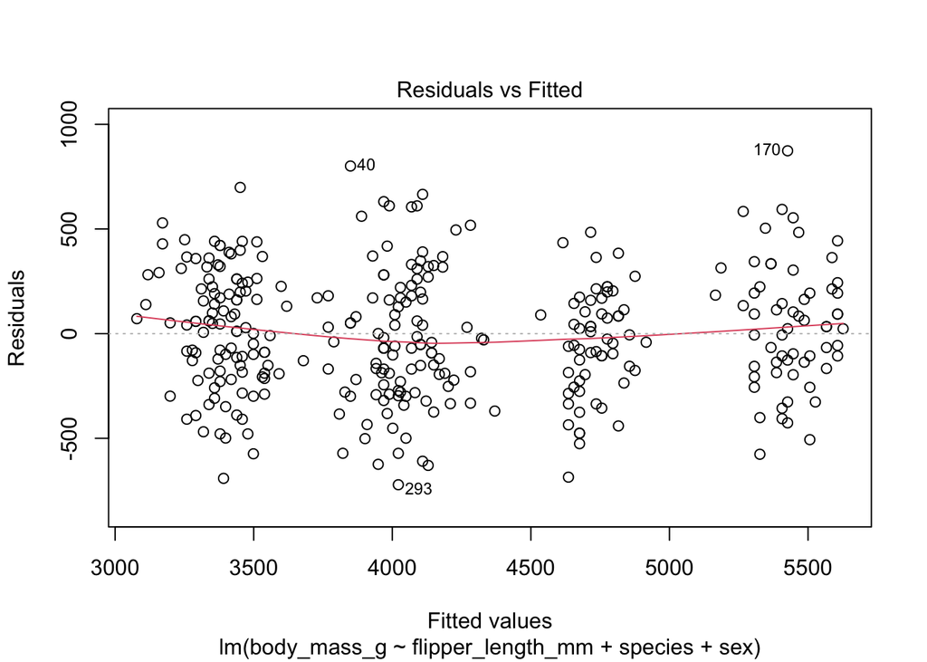

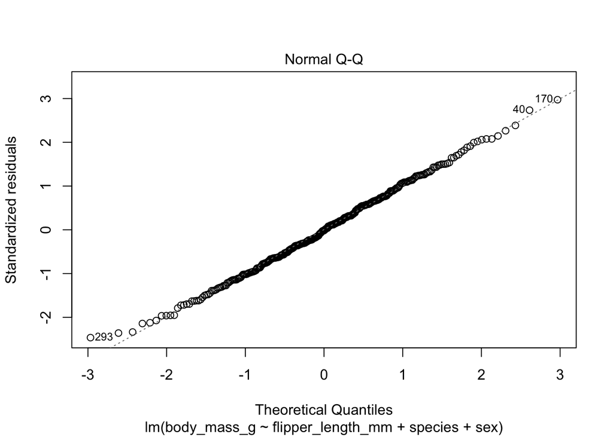

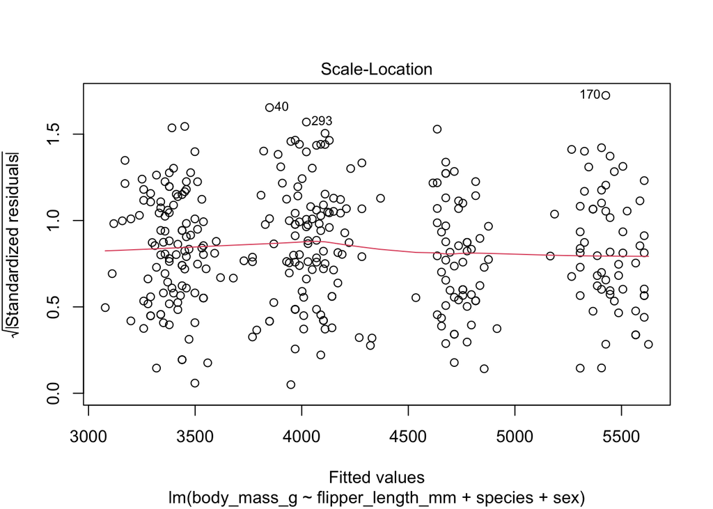

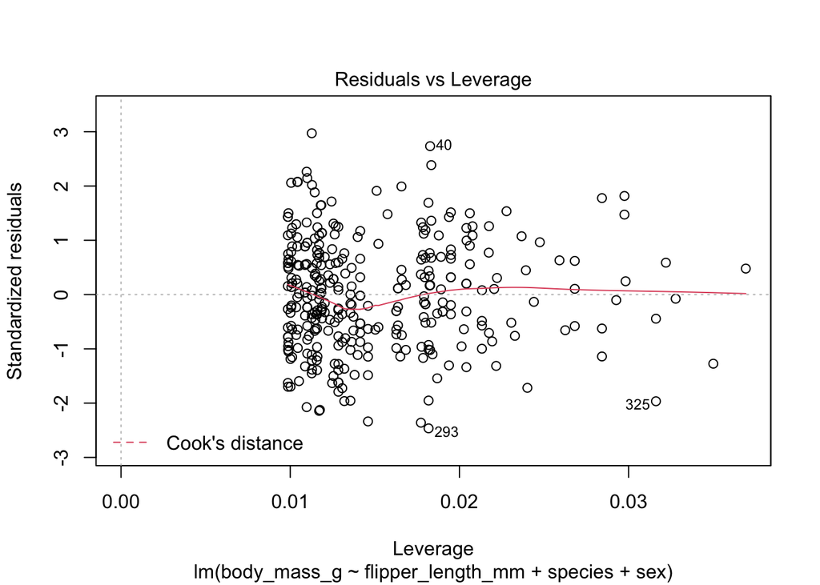

```r
plot(penguin_lm_task) # looking at cooks distance will illustrate outliers in data
```

- Conceptual understanding and expertise allows me to responsibly determine that penguin species, sex, and flipper length are reasonable predictor variable (make sure you’re thinking hard about variables adn different variable combinations)
- Diagnostic plots all check out for normality of residuals, homosedasticity, and no worrisome outliers (<< last one not an assumption)

## Make output tables

- Using modelsummary:

```r
modelsummary(penguin_lm_task)
```

|  | Model 1 |
| --- | --- |
| (Intercept) | −365.817 |
|  | (532.050) |
| flipper_length_mm | 20.025 |
|  | (2.846) |
| speciesChinstrap | −87.634 |
|  | (46.347) |
| speciesGentoo | 836.260 |
|  | (85.185) |
| sexmale | 530.381 |
|  | (37.810) |
| Num.Obs. | 333 |
| R2 | 0.867 |
| R2 Adj. | 0.865 |
| AIC | 4740.8 |
| BIC | 4763.6 |
| Log.Lik. | −2364.387 |
| F | 534.024 |

Using stargazer:

```r
stargazer(penguin_lm_task, type = "html")
```

|  | *Dependent variable:* |
| --- | --- |
|  | body_mass_g |
| flipper_length_mm | 20.025*** |
|  | (2.846) |
| speciesChinstrap | -87.634* |
|  | (46.347) |
| speciesGentoo | 836.260*** |
|  | (85.185) |
| sexmale | 530.381*** |
|  | (37.810) |
| Constant | -365.817 |
|  | (532.050) |
| Observations | 333 |
| R<sup>2</sup> | 0.867 |
| Adjusted R<sup>2</sup> | 0.865 |
| Residual Std. Error | 295.565 (df = 328) |
| F Statistic | 534.024*** (df = 4; 328) |
| *Note:* | p<0.1; p<0.05; p<0.01 |